# 1 Descriptive Representation

This script calculates four measures of descriptive representation for the Urban Institute Mobility Metrics project. The metrics are constructed using the [ICMA Municipal Form of Government 2018 Survey](https://icma.org/2018-municipal-fog-survey) and 5-year ACS data.

```r
options(scipen = 999)

library(tidyverse)
library(readxl)
library(censusapi)

source(here::here("05_local-governance", "R", "census_api_key.R"))
source(here::here("05_local-governance", "R", "get_vars.R"))

theme_set(theme_minimal())
```

The Urban Institute purchased the [ICMA Municipal Form of Government 2018 Survey](https://icma.org/2018-municipal-fog-survey). It is available on Box and needs to be added to this directory in a way that matches the filepath below.

```r
if (!dir.exists("data")) {

  dir.create("data")

}

# read in the ICMA survey
icma2018 <- read_excel(here::here("05_local-governance",
                                  "descriptive-representation",
                                  "data",
                                  "Municipal Form of Government 2018 Survey",
                                  "Municipal Form of Government 2018 Data.xlsx"))

# only keep the relevant ICMA variables
analysis <- icma2018 %>%
  select(ID,
         LocalGovernment,
         state_name = State,
         county_name = County,
         U18POPest,
         FIPS_StateCounty,
         FIPS_Place,
         starts_with("Q35"))
```

### 1.0.1 Recreate Table 35.

We begin by recreating Table 35 from the 2018 Municipal Form of Government Survey Summary of Survey Results. The results match exactly.

```r
# move from wide to long and recode the variable names to race/eth groups
table35 <- analysis %>%
  pivot_longer(cols = starts_with("Q35"),
               names_to = "race_ethnicity",
               values_to = "count") %>%
  mutate(race_ethnicity = case_when(
    race_ethnicity == "Q35_a" ~ "American Indian or Alaska Native",
    race_ethnicity == "Q35_b" ~ "Hispanic or Latino",
    race_ethnicity == "Q35_c" ~ "Asian or Pacific Islander",
    race_ethnicity == "Q35_d" ~ "White, not of Hispanic Origin",
    race_ethnicity == "Q35_e" ~ "Black or African American",
    race_ethnicity == "Q35_f" ~ "Native Hawaiin or Other Pacific Islander",
    race_ethnicity == "Q35_g" ~ "Middle Eastern or North African",
    race_ethnicity == "Q35_h" ~ "Some other race, ethnicity, or origin",
    )
  )

# confirm a = 21,466
table35 %>%
  summarize(sum(count, na.rm = TRUE))
```

```
## # A tibble: 1 x 1
##   `sum(count, na.rm = TRUE)`
##                        <dbl>
## 1                      21466
```

```r
# confirm frequencies from table 35
table35 %>%
  group_by(race_ethnicity) %>%
  summarize(count = sum(count, na.rm = TRUE)) %>%
  mutate(prop = count / sum(count))
```

```
## # A tibble: 8 x 3
##   race_ethnicity                           count     prop
##   <chr>                                    <dbl>    <dbl>
## 1 American Indian or Alaska Native           146 0.00680
## 2 Asian or Pacific Islander                   82 0.00382
## 3 Black or African American                 1329 0.0619
## 4 Hispanic or Latino                         645 0.0300
## 5 Middle Eastern or North African             42 0.00196
## 6 Native Hawaiin or Other Pacific Islander     7 0.000326
## 7 Some other race, ethnicity, or origin       88 0.00410
## 8 White, not of Hispanic Origin            19127 0.891
```

## 1.1 Descriptive Representation Metrics

The metric is the ratio of the share of local elected officials of a racial/ethnic group to the share of residents of the same racial/ethnic group. The four racial/ethnic groups of interest are Asian/other, Black non-Hispanic, Latinx, and white non-Hispanic.

We will use eight steps to create the four metrics:

### 1.1.1 1. Get shares of 4 race/ethnicity groups at the council level from the ICMA survey

The counts of councilmembers of different racial and ethnic groups are expressed as a series of variables beginning with `Q35_`. We rename the variables. The total number of councilmembers is not expressed as an integer in the survey, so we sum the groups.

```r
# replace missing values with zeros
analysis <- analysis %>%
  mutate(across(starts_with("Q35"), .fns = ~replace_na(data = .x, replace = 0))) %>%
  rename(
    american_indian_alaskan_native = Q35_a,
    hispanic_or_latino = Q35_b,
    asian_or_pacific_islander = Q35_c,
    white_nonhispanic = Q35_d,
    black =  Q35_e,
    native_hawaiin_or_pacific_islander = Q35_f,
    middle_eastern_or_north_african = Q35_g,
    other = Q35_h
  )

# sum up the councilmembers
analysis <- analysis %>%
  mutate(council_members =
           american_indian_alaskan_native +
           hispanic_or_latino +
           asian_or_pacific_islander +
           white_nonhispanic +
           black +
           native_hawaiin_or_pacific_islander +
           middle_eastern_or_north_african +
           other)
```

We collapse the eight racial/ethnic groups from ICMA into the four groups of interest.

```r
# collapse into 4 groups
analysis <- analysis %>%
  mutate(
    council_asian_other = american_indian_alaskan_native +
      asian_or_pacific_islander +
      native_hawaiin_or_pacific_islander +
      middle_eastern_or_north_african +
      other,
    council_black_nonhispanic = black,
    council_hispanic = hispanic_or_latino,
    council_white_nonhispanic = white_nonhispanic
  )

# drop old variables
analysis <- analysis %>%
  select(-american_indian_alaskan_native,
         -hispanic_or_latino,
         -asian_or_pacific_islander,
         -black,
         -native_hawaiin_or_pacific_islander,
         -middle_eastern_or_north_african,
         -other,
         -white_nonhispanic)
```

The ICMA survey does not distinguish between `0` and `NA`. We calculate the share of councilmembers by race and turn council shares into `NA` for municipalities that have zero councilmembers.

```r
calc_council_proportion <- function(council_race, council_members) {

  if_else(condition = council_members == 0,
              true = as.numeric(NA),
              false = {{council_race}} / council_members)

}

analysis <- analysis %>%
  mutate(
    council_asian_other = calc_council_proportion(council_asian_other,
                                                  council_members),
    council_black_nonhispanic = calc_council_proportion(council_black_nonhispanic,
                                                  council_members),
    council_hispanic = calc_council_proportion(council_hispanic,
                                                  council_members),
    council_white_nonhispanic = calc_council_proportion(council_white_nonhispanic,
                                                  council_members)
  )
```

We test to ensure that the ratios are bounded by 0 and 1 inclusive.

```r
# bounded by 0 and 1
stopifnot(
  analysis %>%
    filter(
      council_asian_other < 0 | council_asian_other > 1 |
        council_black_nonhispanic < 0 | council_black_nonhispanic > 1|
        council_hispanic < 0 | council_hispanic > 1 |
        council_white_nonhispanic < 0 | council_white_nonhispanic > 1
    ) %>%
    nrow() == 0
)
```

- todo(aaron): Test number of councilmembers
- todo(aaron): Compare with other questions

### 1.1.2 2. Pull demographics for Census places and Census County Subdivisions

We pull the share of the population that belongs to different racial/ethnic in Census places and Census county subdivisions.

We pull all of the race/ethnicity counts for 2018 using `library(censusapi)`. **Note:** This will require a [Census API key](https://api.census.gov/data/key_signup.html). Add the key to `census_api_key-template.R` and then delete then delete “template”. It is sourced above.

```r
# list variable of interest
vars <- c(
  # Hispanic or Latino
  "DP05_0071E", # Estimate!!HISPANIC OR LATINO AND RACE!!Total population!!Hispanic or Latino (of any race)
  "DP05_0071M",
  # Not Hispanic or Latino
  "DP05_0077E", # White alone
  "DP05_0077M",
  "DP05_0078E", # Black or African American alone
  "DP05_0078M",
  "DP05_0079E", # American Indian and Alaska Native alone
  "DP05_0079M",
  "DP05_0080E", # Asian alone
  "DP05_0080M",
  "DP05_0081E", # Native Hawaiian and Other Pacific Islander alone
  "DP05_0081M",
  "DP05_0082E", # Some other race alone
  "DP05_0082M",
  "DP05_0083E", # Two or more races
  "DP05_0083M"
)

# pull ACS data at the Census Place and Census County Subdivision levels
places <- get_vars(year = 2018, vars = vars, geography = "place")
county_subdivisions <- get_vars(year = 2018, vars = vars, geography = "county subdivision")

# combine the two geographies
geographies <- bind_rows(places, county_subdivisions)

rm(places, county_subdivisions)

# give meaningful names
geographies <- geographies %>%
  rename(
    people = B01003_001E,
    hispanic = DP05_0071E,
    hispanic_moe = DP05_0071M,
    white_nonhispanic = DP05_0077E,
    white_nonhispanic_moe = DP05_0077M,
    black_nonhispanic = DP05_0078E,
    black_nonhispanic_moe = DP05_0078M,
    aian_nh = DP05_0079E,
    aian_nh_moe = DP05_0079M,
    asian_nh = DP05_0080E,
    asian_nh_moe = DP05_0080M,
    nhpi_nh = DP05_0081E,
    nhpi_nh_moe = DP05_0081M,
    other_nh = DP05_0082E,
    other_nh_moe = DP05_0082M,
    two_or_more_nh = DP05_0083E,
    two_or_more_nh_moe = DP05_0083M
  )
```

The Census reports race and ethnicity as many different groups. Table 2 in [this publication](https://www.census.gov/prod/cen2010/briefs/c2010br-02.pdf) is helpful. Here, we collapse the detailed groups into the same four groups of interest from the above section.

```r
# construct asian_other
geographies <- geographies %>%
  mutate(asian_other = aian_nh + asian_nh + nhpi_nh + other_nh + two_or_more_nh) %>%
  select(state,
         county,
         place,
         county_subdivision,
         people, asian_other,
         black_nonhispanic,
         hispanic,
         white_nonhispanic,
         geography)

# test that the new groups sum to the original people total
stopifnot(
  geographies %>%
    mutate(people2 = asian_other + black_nonhispanic + hispanic + white_nonhispanic) %>%
    filter(people != people2) %>%
    nrow() == 0
)
```

We calculate the share of municipalities by race.

```r
geographies <- geographies %>%
  mutate(
    asian_other = asian_other / people,
    black_nonhispanic = black_nonhispanic / people,
    hispanic = hispanic / people,
    white_nonhispanic = white_nonhispanic / people
  )

# test to see if bounded by 0 and 1
stopifnot(
  geographies %>%
    filter(
      asian_other < 0 | asian_other > 1 |
        black_nonhispanic < 0 | black_nonhispanic > 1|
        hispanic < 0 | hispanic > 1 |
        white_nonhispanic < 0 | white_nonhispanic > 1
    ) %>%
    nrow() == 0
)

# test to see if the 4 categories sum to 1
stopifnot(
  geographies %>%
    mutate(total = round(asian_other + black_nonhispanic + hispanic + white_nonhispanic, 10)) %>%
    filter(total != 1) %>%
    nrow() == 0
)
```

### 1.1.3 3. Join the Census data to the ICMA data

`FIPS_Place` in the ICMA data is actually combination of Census Places and Census County Subdivisions. Here’s a note from Will Fricke at ICMA:

> I meant to add this in the READ ME txt file: The FIPS_place column includes both place and county subdivision codes (I suppose the column should have a different name) – if you go back through ICMA datasets you’ll find it’s consistently done that way regardless of the wisdom of it.

> The method I use to merge census data into our datasets is to use a vlookup in excel from the FIPS_place column to the Census data place codes column, and then the same thing from the N/A rows to the COUSUB codes column. (Check to make sure you have enough RAM first…)

We pull a list of all Census geographies from [here](https://www.census.gov/geographies/reference-files.html).

```r
# load a list of all FIPS
fips <- read_excel(here::here("05_local-governance",
                              "descriptive-representation",
                              "fips", "all-geocodes-v2018.xlsx"),
                   skip = 4) %>%
  mutate(FIPS_Place = paste0(`State Code (FIPS)`, `Place Code (FIPS)`))

# create 7- and 10- digit codes in fips
fips <- fips %>%
  mutate(place_code = paste0(`State Code (FIPS)`, `Place Code (FIPS)`),
         county_subdivision_code = paste0(`State Code (FIPS)`,
                                          `County Code (FIPS)`,
                                          `County Subdivision Code (FIPS)`))

# create 7- and 10- digit codes in geographies
geographies <- geographies %>%
  mutate(place_code = paste0(state, place),
         county_subdivision_code = str_c(state, county, county_subdivision))
```

If a locality from the ICMA data is a Census place then assign Census place. If a locality isn’t a Census place then assign Census County Subdivision.

```r
# if a place, use place
analysis <- analysis %>%
  # create a potential code
  mutate(potential_place = str_c(str_sub(FIPS_StateCounty, start = 1, end = 2), FIPS_Place)) %>%
  mutate(place_code = if_else(potential_place %in% pull(fips, place_code),
                              true = potential_place,
                              false = as.character(NA)))

# if not a place, then a county subdivision
analysis <- analysis %>%
  # create a potential code
  mutate(potential_county_subdivision_code = str_c(FIPS_StateCounty, FIPS_Place)) %>%
  mutate(county_subdivision_code = if_else(potential_county_subdivision_code %in% pull(fips, county_subdivision_code),
                                          true = potential_county_subdivision_code,
                                          false = as.character(NA)))

# create geography variable
analysis <- analysis %>%
  select(-potential_place, -potential_county_subdivision_code) %>%
  mutate(geography = case_when(
    !is.na(place_code) ~ "place",
    !is.na(county_subdivision_code) ~ "county subdivision"
    ))

# cases without a place or a county subdivision
trouble <- tidylog::filter(analysis, is.na(geography)) %>%
  mutate(geography = "trouble")

# join the Census places
places <- geographies %>%
  tidylog::filter(geography == "place") %>%
  select(-county, -county_subdivision, -county_subdivision_code)

places <- analysis %>%
  select(-county_subdivision_code) %>%
  tidylog::filter(geography == "place") %>%
  left_join(places, by = c("place_code", "geography"))
```

Combine the three data (places, county subdivisions, trouble) into one file.

```r
# join the Census county subdivisions
county_subdivisions <- geographies %>%
  tidylog::filter(geography == "county subdivision") %>%
  select(-place, -place_code)

county_subdivisions <- analysis %>%
  tidylog::filter(geography == "county subdivision") %>%
  select(-place_code) %>%
  left_join(county_subdivisions, by = c("county_subdivision_code", "geography"))

# combine three joined data sets into one data set
joined_data <- bind_rows(
  places,
  county_subdivisions,
  trouble
) %>%
  mutate(state = str_sub(FIPS_StateCounty, start = 1, end = 2),
         county = str_sub(FIPS_StateCounty, start = 3, end = 5))
```

Quality checks:

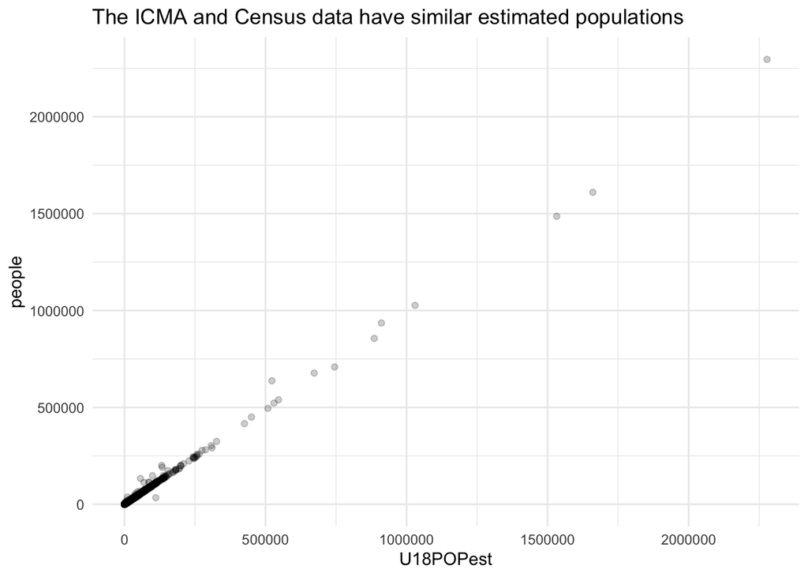

```r
ggplot(joined_data, aes(U18POPest, people)) +
  geom_point(alpha = 0.2) +
  labs(title = "The ICMA and Census data have similar estimated populations")
```

### 1.1.4 4. Calculate the metrics

Find the ratio of the proportions. Conditional logic is needed to avoid division by `0`.

```r
joined_data <- joined_data %>%
  mutate(
    asian_other =
      if_else(condition = asian_other == 0,
              true = 0,
              false = council_asian_other / asian_other),
    black_nonhispanic =
      if_else(condition = black_nonhispanic == 0,
              true = 0,
              false = council_black_nonhispanic / black_nonhispanic),
    hispanic =
      if_else(condition = hispanic == 0,
              true = 0,
              false = council_hispanic / hispanic),
    white_nonhispanic =
      if_else(condition = white_nonhispanic == 0,
              true = 0,
              false = council_white_nonhispanic / white_nonhispanic)
  ) %>%
  select(-council_asian_other,
         -council_black_nonhispanic,
         -council_hispanic,
         -council_white_nonhispanic)
```

Ensure that there are no undefined numbers.

```r
stopifnot(
  filter(joined_data, is.nan(black_nonhispanic)) %>%
    nrow() == 0
)
```

### 1.1.5 5. Aggregate to the county level

We now have the four metrics of interest for municipalities. We need to roll these up to counties.

```r
# drop municipalities that don't report ICMA data and drop municipalities without matches
joined_data <- joined_data %>%
  tidylog::filter(council_members > 0) %>%
  tidylog::filter(geography != "trouble")

# find the person-weighted average of the four metrics at the county level
county_data <- joined_data %>%
  group_by(state, county) %>%
  summarize(municipalities = n(),
            asian_other = sum(asian_other * people) / sum(people),
            black_nonhispanic = sum(black_nonhispanic * people) / sum(people),
            hispanic = sum(hispanic * people) / sum(people),
            white_nonhispanic = sum(white_nonhispanic * people) / sum(people),
            people = sum(people)) %>%
  ungroup()
```

We only have a fraction of the county population for many counties. We calculate the proportion represented.

```r
# pull the county population using tidycensus
county_pop <- tidycensus::get_acs(geography = "county",
                                  variable = c(people = "B01003_001E"),
                                  year = 2018) %>%
  mutate(state = str_sub(GEOID, start = 1, end = 2),
         county = str_sub(GEOID, start = 3, end = 5)) %>%
  select(county_state = NAME,
         state,
         county,
         people_county = estimate)

# calculate the share of the county population represented
county_data <- left_join(county_data, county_pop, by = c("state", "county"))

county_data <- county_data %>%
  mutate(population_prop = people / people_county)
```

Quality checks:

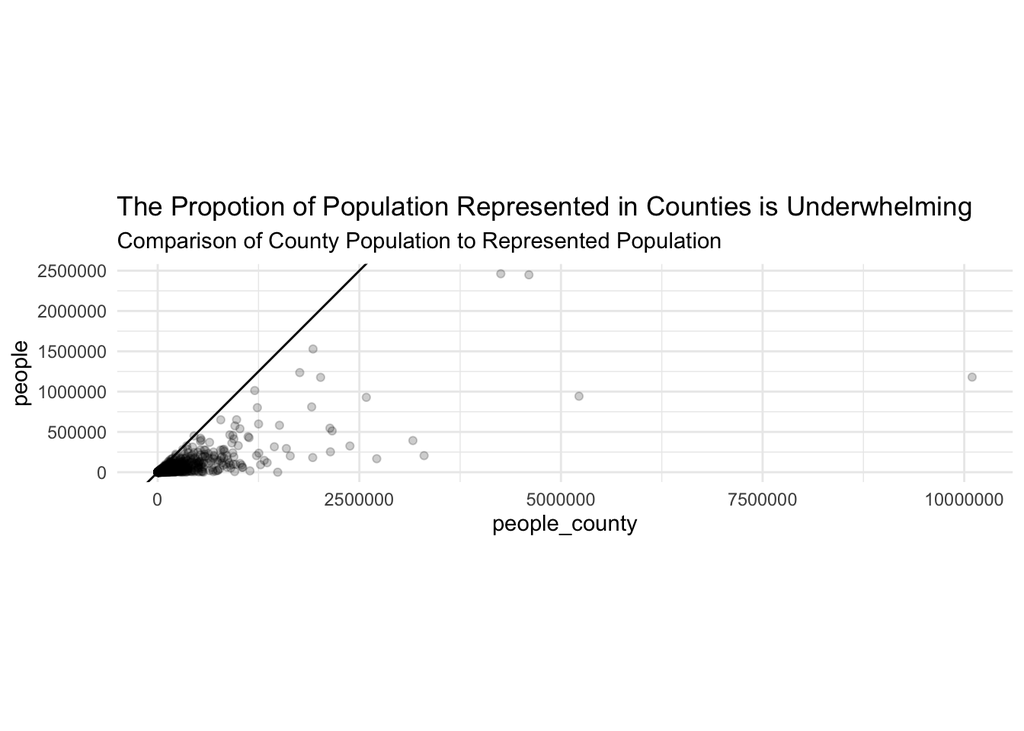

```r
ggplot(county_data, aes(people_county, people)) +
  geom_point(alpha = 0.2) +
  geom_abline(slope = 1) +
  coord_equal() +
  labs(title = "The Propotion of Population Represented in Counties is Underwhelming",
       subtitle = "Comparison of County Population to Represented Population")
```

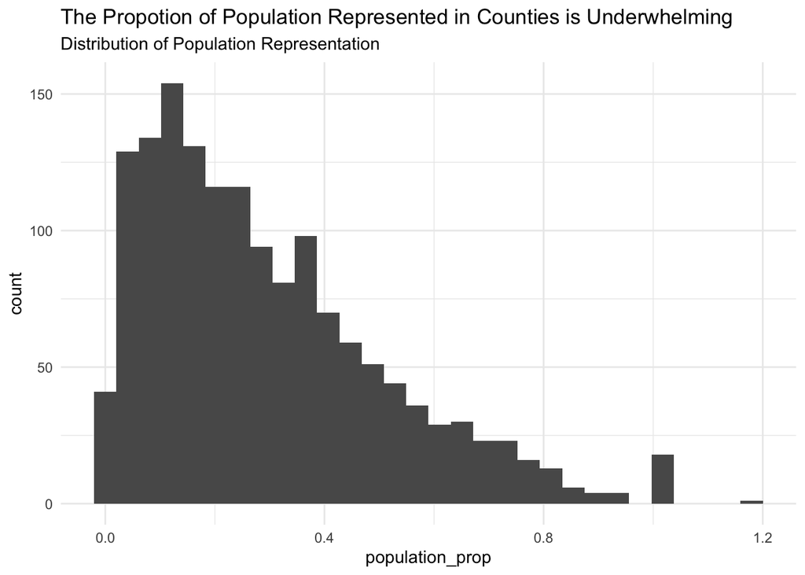

```r
county_data %>%
  ggplot(aes(population_prop)) +
  geom_histogram() +
  labs(title = "The Propotion of Population Represented in Counties is Underwhelming",
       subtitle = "Distribution of Population Representation")
```

### 1.1.7 7. Create quality flags

The municipality-level data are accurate and useful. The representativeness of the county-level data is questionable because many municipalities are missing from the summarized data.

- `1` if > 80% of population is captured.
- `2` if > 50% of the population is captured.
- `3` otherwise.

```r
# create a helper function for data quality
set_quality <- function(proportion) {

  quality <- case_when(
    proportion >= 0.8 ~ 1,
    proportion >= 0.5 ~ 2,
    proportion >= 0 ~ 3
  )

  return(quality)

}

# quality flags
county_data <- county_data %>%
  mutate(
    asian_other_quality = set_quality(proportion = population_prop),
    black_nonhispanic_quality = set_quality(proportion = population_prop),
    hispanic_quality = set_quality(proportion = population_prop),
    white_nonhispanic_quality = set_quality(proportion = population_prop)
  )

count(county_data, asian_other_quality)
```

```
## # A tibble: 3 x 2
##   asian_other_quality     n
##                 <dbl> <int>
## 1                   1    44
## 2                   2   215
## 3                   3  1262
```

```r
count(county_data, black_nonhispanic_quality)
```

```
## # A tibble: 3 x 2
##   black_nonhispanic_quality     n
##                       <dbl> <int>
## 1                         1    44
## 2                         2   215
## 3                         3  1262
```

```r
count(county_data, hispanic_quality)
```

```
## # A tibble: 3 x 2
##   hispanic_quality     n
##              <dbl> <int>
## 1                1    44
## 2                2   215
## 3                3  1262
```

```r
count(county_data, white_nonhispanic_quality)
```

```
## # A tibble: 3 x 2
##   white_nonhispanic_quality     n
##                       <dbl> <int>
## 1                         1    44
## 2                         2   215
## 3                         3  1262
```

### 1.1.8 8. Save the data

We need to include all counties in the published data even if we don’t have a metric for the county. We load the county file and join our metrics to the county file.

```r
# load the 2018 county file
all_counties <- read_csv(here::here("geographic-crosswalks", "data", "county-file.csv")) %>%
  tidylog::filter(year == 2018)

# join the calculated metrics to the full file
all_counties <- left_join(all_counties, county_data, by = c("state", "county"))

# final data set
all_counties <- all_counties %>%
  mutate(year = 2018) %>%
  select(year,
         state,
         county,
         asian_other,
         asian_other_quality,
         black_nonhispanic,
         black_nonhispanic_quality,
         hispanic,
         hispanic_quality,
         white_nonhispanic,
         white_nonhispanic_quality)

write_csv(all_counties, here::here("05_local-governance",
                                   "descriptive-representation",
                                   "descriptive-representation.csv"))
```